# Creating Customer Segmentation Report for Arvato Financial Services

In this project, I have analyzed demographics data for customers of a mail-order sales company in Germany, comparing it against demographics information for the general population. I have used unsupervised learning techniques to perform customer segmentation, identifying the parts of the population that best describe the core customer base of the company. Then I have used demographics information for targets of a marketing campaign for the company, and used a model to predict which individuals are most likely to convert into becoming customers for the company. The data that I have used has been provided by Bertelsmann Arvato Analytics.

```python
import numpy as np
import pandas as pd
import matplotlib.pyplot as plt
import seaborn as sns
import pprint
import operator
import time
from sklearn.preprocessing import Imputer
from sklearn.cluster import KMeans
from sklearn.preprocessing import StandardScaler
from sklearn.decomposition import PCA
from sklearn.preprocessing import LabelEncoder
import chardet
%matplotlib inline
from sklearn.svm import SVC
from sklearn.model_selection import GridSearchCV
from sklearn.model_selection import train_test_split
from sklearn.pipeline import Pipeline
from sklearn.tree import DecisionTreeClassifier
from sklearn.ensemble import AdaBoostClassifier
from sklearn.metrics import f1_score, roc_auc_score
import seaborn as sns
```

## Datasets

```python
azdias = pd.read_csv('../../data/Term2/capstone/arvato_data/Udacity_AZDIAS_052018.csv', sep=';', dtype=str)
customers = pd.read_csv('../../data/Term2/capstone/arvato_data/Udacity_CUSTOMERS_052018.csv', sep=';', dtype=str)
```

```python
azdias.head()
```

|  | LNR | AGER_TYP | AKT_DAT_KL | ALTER_HH | ALTER_KIND1 | ALTER_KIND2 | ALTER_KIND3 | ALTER_KIND4 | ALTERSKATEGORIE_FEIN | ANZ_HAUSHALTE_AKTIV | ... | VHN | VK_DHT4A | VK_DISTANZ | VK_ZG11 | W_KEIT_KIND_HH | WOHNDAUER_2008 | WOHNLAGE | ZABEOTYP | ANREDE_KZ | ALTERSKATEGORIE_GROB |
| --- | --- | --- | --- | --- | --- | --- | --- | --- | --- | --- | --- | --- | --- | --- | --- | --- | --- | --- | --- | --- | --- |
| 0 | 910215 | -1 | NaN | NaN | NaN | NaN | NaN | NaN | NaN | NaN | ... | NaN | NaN | NaN | NaN | NaN | NaN | NaN | 3 | 1 | 2 |
| 1 | 910220 | -1 | 9 | 0 | NaN | NaN | NaN | NaN | 21 | 11 | ... | 4 | 8 | 11 | 10 | 3 | 9 | 4 | 5 | 2 | 1 |
| 2 | 910225 | -1 | 9 | 17 | NaN | NaN | NaN | NaN | 17 | 10 | ... | 2 | 9 | 9 | 6 | 3 | 9 | 2 | 5 | 2 | 3 |
| 3 | 910226 | 2 | 1 | 13 | NaN | NaN | NaN | NaN | 13 | 1 | ... | 0 | 7 | 10 | 11 | NaN | 9 | 7 | 3 | 2 | 4 |
| 4 | 910241 | -1 | 1 | 20 | NaN | NaN | NaN | NaN | 14 | 3 | ... | 2 | 3 | 5 | 4 | 2 | 9 | 3 | 4 | 1 | 3 |

5 rows × 366 columns

```python
azdias.shape
```

```
(891221, 366)
```

```python
azdias["LNR"].nunique()
```

```
891221
```

It seems like each row has unique LNR value.

```python
customers.shape
```

```
(191652, 369)
```

```python
customers["LNR"].nunique() == customers.shape[0]
```

```
True
```

```python
np.intersect1d(azdias["LNR"], customers["LNR"])
```

```
array([], dtype=object)
```

## Dealing with missing data

This dataframe will help in replacing the values indicating missing data with `None` during the cleaning step.

```python
feat_info = pd.read_csv("features.csv")
```

```python
feat_info.head()
```

|  | attribute | information_level | type | missing_or_unknown | Comment |
| --- | --- | --- | --- | --- | --- |
| 0 | AGER_TYP | person | categorical | [-1,0] | NaN |
| 1 | ALTER_HH | household | interval | [0] | NaN |
| 2 | ALTERSKATEGORIE_GROB | person | ordinal | [-1,0,9] | NaN |
| 3 | ANREDE_KZ | person | categorical | [-1,0] | NaN |
| 4 | ANZ_HAUSHALTE_AKTIV | building | numeric | [0] | NaN |

```python
azdias_cleaned = azdias.copy()
```

```python
for index, row in feat_info.iterrows():
    attribute, information_level, var_type, missing, comment = row
    if attribute in azdias_cleaned.columns:
        values = missing.replace("[","").replace("]","").split(",")
        replacement = {}
        for value in values:
            value = value.strip()
            replacement[value] = None
        azdias_cleaned.loc[:, attribute].replace(replacement, inplace=True)
```

```python
# Perform an assessment of how much missing data there is in each column of the
# dataset.
missing = azdias_cleaned.isnull().sum()
missing = missing[missing > 0]/(azdias.shape[0]) * 100
missing.sort_values(inplace=True)
```

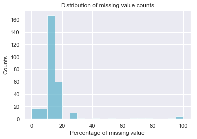

```python
plt.hist(missing, bins=20, facecolor='c', alpha=0.75)
plt.xlabel('Percentage of missing value')
plt.ylabel('Counts')
plt.title('Distribution of missing value counts')
plt.grid(True)
plt.show()
```

```python
missing_20 = [col for col in azdias_cleaned.columns if (azdias[col].isnull().sum()/azdias_cleaned.shape[0]) * 100 > 20]
print(missing_20)
```

```
['ALTER_KIND1', 'ALTER_KIND2', 'ALTER_KIND3', 'ALTER_KIND4', 'ALTERSKATEGORIE_FEIN', 'D19_BANKEN_ONLINE_QUOTE_12', 'D19_GESAMT_ONLINE_QUOTE_12', 'D19_KONSUMTYP', 'D19_LETZTER_KAUF_BRANCHE', 'D19_LOTTO', 'D19_SOZIALES', 'D19_TELKO_ONLINE_QUOTE_12', 'D19_VERSAND_ONLINE_QUOTE_12', 'D19_VERSI_ONLINE_QUO…
```

I have decided to drop these columns during the data cleaning step as the columns with more than 20% missing values look like outliers among all the columns as most of the columns have less than 20% missing values.

```python
few_missing = azdias_cleaned[cols_less_than_20_missing][azdias_cleaned[cols_less_than_20_missing].isnull().sum(axis=1) < 20].reset_index(drop=True)
high_missing = azdias_cleaned[cols_less_than_20_missing][azdias_cleaned[cols_less_than_20_missing].isnull().sum(axis=1) >= 20].reset_index(drop=True)
```

```python
cols_with_least_missing_values = missing.sort_values().index[:5]
```

```python
few_missing.iloc[:, 1].value_counts().sort_index()/few_missing.shape[0]
```

```
1    0.104657
2    0.119114
3    0.032928
Name: AGER_TYP, dtype: float64
```

```python
high_missing.iloc[:, 1].value_counts().sort_index()/high_missing.shape[0]
```

```
1    0.019621
2    0.070598
3    0.018775
Name: AGER_TYP, dtype: float64
```

```python
print ("Difference in the proportion of samples with given value in percentage between rows with few missing values and rows with many missing values")
for col in cols_with_least_missing_values:
    print ("\nColumn: {}".format(col))
    print(100 * (few_missing.loc[:, col].value_counts().sort_index()/few_missing.shape[0] - high_missing.loc[:, col].value_counts().sort_index()/high_missing.shape[0]))
```

```
Difference in the proportion of samples with given value in percentage between rows with few missing values and rows with many missing values

Column: ALTERSKATEGORIE_GROB
1    -2.322733
2    -3.652445
3    -7.644974
4    13.471156
Name: ALTERSKATEGORIE_GROB, dtype: float64

Column: RETOURTYP_BK_S
1     6.536589
2     5.387447
3   -23.719107
4     2.755688
5    12.103680
Name: RETOURTYP_BK_S, dtype: float64

Column: RT_SCHNAEPPCHEN
1     4.249991
2     8.135772
3     7.390354
4     6.340904
5   -23.052723
Name: RT_SCHNAEPPCHEN, dtype: float64

Column: LP_STATUS_GROB
1    16.945056
2   -20.221301
3     1.183501
4    -0.716384
5     5.873425
Name: LP_STATUS_GROB, dtype: float64

Column: LP_STATUS_FEIN
1      9.837824
10     5.873425
2      7.107232
3      3.341546
4      4.730902
5    -28.293749
6      0.976300
7      0.207201
8     -1.706803
9      0.990419
Name: LP_STATUS_FEIN, dtype: float64
```

As we can see from the above figures that there is significant difference between the distributions of the values in the rows with large number of missing values vs. low number of missing values. This suggests that the missing values are more likely to be present in rows with specific distribution of values in other columns with few missing values. This means that it is not a good idea to drop the rows with missing values and instead we need to fill them with some meaningful value. For the categorical, ordinal and interval type columns, it makes sense to fill the missing values with Mode of the column.

Column "flag indicating the former GDR/FRG" contains categorical values 'W' and 'O' which needs to be converted into binary numerical values.

For the purpose of using in PCA, I have only retained columns that have less that 30 ordinal level values during the cleaning process.

Below is the method that encodes all the cleaning steps described above. This method can be called on both population data as well as customers data.

```python
def clean_data(df_input):
    """
    Takes data frame as input.
    Performs required cleaning steps to convert it into a dataframe useful for further analysis.
    Input:
    - df_input : Dataframe to be cleaned
    Output:
    - df : Cleaned dataframe
    """
    df = df_input.copy()
    print ("Copied")

    for index, row in feat_info.iterrows():
        attribute, information_level, var_type, missing, comment = row
        if attribute in df.columns:
            values = missing.replace("[","").replace("]","").split(",")
            replacement = {}
            for value in values:
                value = value.strip()
                replacement[value] = None
            df.loc[:, attribute].replace(replacement, inplace=True)

    print("Replaced unknown with None")
    df.replace({"-1": None, 'X': None, 'XX': None}, inplace=True)
    print ("Replaced -1, X, XX with None")
    recode = ['D19_BANKEN_DATUM', 'D19_BANKEN_OFFLINE_DATUM',
       'D19_BANKEN_ONLINE_DATUM', 'D19_GESAMT_DATUM',
       'D19_GESAMT_OFFLINE_DATUM', 'D19_GESAMT_ONLINE_DATUM',
       'D19_TELKO_DATUM', 'D19_TELKO_OFFLINE_DATUM',
       'D19_TELKO_ONLINE_DATUM', 'D19_VERSAND_DATUM',
       'D19_VERSAND_OFFLINE_DATUM', 'D19_VERSAND_ONLINE_DATUM',
       'D19_VERSI_DATUM', 'D19_VERSI_OFFLINE_DATUM',
       'D19_VERSI_ONLINE_DATUM']
    to_be_recoded = [col for col in df.columns if col in recode]
    df[to_be_recoded] = df[to_be_recoded].replace("10", "0")
    col_select = (df.isna().sum(axis=0)/df.shape[0]) <= 0.20
    df = df.loc[:, col_select]
    print ("Retained columns with only few missing values")
    df = df.loc[:, df.nunique() <= 30]
    print ("Retained columns with limited levels")
    def fill_mode(col):
        return col.fillna(col.mode()[0])
    df = df.apply(fill_mode, axis=0)
    print ("Filled Nan with Mode")

    numbers = [str(x) for x in range(100)]
    for col in df.columns:
        level = 0
        for value in df[col].unique():
            if value not in numbers:
                df.loc[df[col] == value, col] = level
                print(col + " " + str(df[col].unique()))
                print("Replaced {} with {}".format(value, level))
                level += 1
    df = df.astype(float)
    print ("Converted to numeric")
    return df
```

```python
common_cols = np.intersect1d(customers.columns, azdias.columns)
```

```python
cust = clean_data(customers[common_cols])
```

```
Copied
Replaced unknown with None
Replaced -1, X, XX with None
Retained columns with only few missing values
Retained columns with limited levels
Filled Nan with Mode
Converted to numeric
```

```python
pop = clean_data(azdias[common_cols])
```

```
Copied
Replaced unknown with None
Replaced -1, X, XX with None
Retained columns with only few missing values
Retained columns with limited levels
Filled Nan with Mode
OST_WEST_KZ [0 'O']
Replaced W with 0
OST_WEST_KZ [0 1]
Replaced O with 1
Converted to numeric
```

```python
cust.to_csv("cust.csv", index=False, header=True, sep=";")
```

```python
pop.to_csv("pop.csv", index=False, header=True, sep=";")
```

## Customer Segmentation Report

Here I have used unsupervised learning techniques (PCA) to describe the relationship between the demographics of the company's existing customers and the general population of Germany. By the end of this part, I have described parts of the general population that are more likely to be part of the mail-order company's main customer base.

```python
cust = pd.read_csv("cust.csv", sep=";")
pop = pd.read_csv("pop.csv", sep=";")
```

```python
cust.head()
```

|  | ALTERSKATEGORIE_GROB | ANREDE_KZ | CJT_GESAMTTYP | CJT_KATALOGNUTZER | CJT_TYP_1 | CJT_TYP_2 | CJT_TYP_3 | CJT_TYP_4 | CJT_TYP_5 | CJT_TYP_6 | ... | SEMIO_KULT | SEMIO_LUST | SEMIO_MAT | SEMIO_PFLICHT | SEMIO_RAT | SEMIO_REL | SEMIO_SOZ | SEMIO_TRADV | SEMIO_VERT | ZABEOTYP |
| --- | --- | --- | --- | --- | --- | --- | --- | --- | --- | --- | --- | --- | --- | --- | --- | --- | --- | --- | --- | --- | --- |
| 0 | 4.0 | 1.0 | 5.0 | 4.0 | 1.0 | 1.0 | 5.0 | 5.0 | 5.0 | 5.0 | ... | 4.0 | 7.0 | 6.0 | 2.0 | 1.0 | 2.0 | 6.0 | 1.0 | 6.0 | 3.0 |
| 1 | 4.0 | 1.0 | 6.0 | 5.0 | 1.0 | 1.0 | 5.0 | 5.0 | 5.0 | 5.0 | ... | 4.0 | 5.0 | 6.0 | 4.0 | 1.0 | 2.0 | 3.0 | 1.0 | 7.0 | 3.0 |
| 2 | 4.0 | 2.0 | 2.0 | 5.0 | 2.0 | 2.0 | 5.0 | 5.0 | 5.0 | 5.0 | ... | 1.0 | 7.0 | 3.0 | 4.0 | 2.0 | 1.0 | 2.0 | 1.0 | 3.0 | 3.0 |
| 3 | 4.0 | 1.0 | 2.0 | 5.0 | 1.0 | 1.0 | 5.0 | 5.0 | 5.0 | 5.0 | ... | 4.0 | 5.0 | 4.0 | 3.0 | 3.0 | 3.0 | 6.0 | 4.0 | 7.0 | 1.0 |
| 4 | 3.0 | 1.0 | 6.0 | 4.0 | 3.0 | 3.0 | 3.0 | 4.0 | 3.0 | 3.0 | ... | 5.0 | 6.0 | 6.0 | 5.0 | 5.0 | 4.0 | 4.0 | 4.0 | 5.0 | 1.0 |

5 rows × 101 columns

```python
pop.head()
```

|  | AKT_DAT_KL | ALTERSKATEGORIE_GROB | ANREDE_KZ | ANZ_HH_TITEL | ANZ_KINDER | ANZ_PERSONEN | ANZ_TITEL | ARBEIT | BALLRAUM | CAMEO_DEUG_2015 | ... | VERS_TYP | VHA | VHN | VK_DHT4A | VK_DISTANZ | VK_ZG11 | WOHNDAUER_2008 | WOHNLAGE | W_KEIT_KIND_HH | ZABEOTYP |
| --- | --- | --- | --- | --- | --- | --- | --- | --- | --- | --- | --- | --- | --- | --- | --- | --- | --- | --- | --- | --- | --- |
| 0 | 1.0 | 2.0 | 1.0 | 0.0 | 0.0 | 1.0 | 0.0 | 4.0 | 6.0 | 8.0 | ... | 2.0 | 0.0 | 2.0 | 10.0 | 10.0 | 10.0 | 9.0 | 3.0 | 6.0 | 3.0 |
| 1 | 9.0 | 1.0 | 2.0 | 0.0 | 0.0 | 2.0 | 0.0 | 3.0 | 6.0 | 8.0 | ... | 2.0 | 0.0 | 4.0 | 8.0 | 11.0 | 10.0 | 9.0 | 4.0 | 3.0 | 5.0 |
| 2 | 9.0 | 3.0 | 2.0 | 0.0 | 0.0 | 1.0 | 0.0 | 3.0 | 2.0 | 4.0 | ... | 1.0 | 0.0 | 2.0 | 9.0 | 9.0 | 6.0 | 9.0 | 2.0 | 3.0 | 5.0 |
| 3 | 1.0 | 4.0 | 2.0 | 0.0 | 0.0 | 0.0 | 0.0 | 2.0 | 4.0 | 2.0 | ... | 1.0 | 1.0 | 0.0 | 7.0 | 10.0 | 11.0 | 9.0 | 7.0 | 6.0 | 3.0 |
| 4 | 1.0 | 3.0 | 1.0 | 0.0 | 0.0 | 4.0 | 0.0 | 4.0 | 2.0 | 6.0 | ... | 2.0 | 0.0 | 2.0 | 3.0 | 5.0 | 4.0 | 9.0 | 3.0 | 2.0 | 4.0 |

5 rows × 335 columns

```python
scaler = StandardScaler()
```

Both the dataframes population and customers need to have same columns to be able to apply Principal Component Analysis technique with PCA model fitted using population data and then used to transform the customer data.

```python
common_cols = np.intersect1d(pop.columns, cust.columns)
```

```python
pop_float = pop[common_cols]
```

```python
pop_scaled = pd.DataFrame(scaler.fit_transform(pop_float.values), columns=pop_float.columns)
```

```python
pop_float.head()
```

|  | ALTERSKATEGORIE_GROB | ANREDE_KZ | CJT_GESAMTTYP | CJT_KATALOGNUTZER | CJT_TYP_1 | CJT_TYP_2 | CJT_TYP_3 | CJT_TYP_4 | CJT_TYP_5 | CJT_TYP_6 | ... | SEMIO_KULT | SEMIO_LUST | SEMIO_MAT | SEMIO_PFLICHT | SEMIO_RAT | SEMIO_REL | SEMIO_SOZ | SEMIO_TRADV | SEMIO_VERT | ZABEOTYP |
| --- | --- | --- | --- | --- | --- | --- | --- | --- | --- | --- | --- | --- | --- | --- | --- | --- | --- | --- | --- | --- | --- |
| 0 | 2.0 | 1.0 | 2.0 | 5.0 | 1.0 | 1.0 | 5.0 | 5.0 | 5.0 | 5.0 | ... | 3.0 | 5.0 | 5.0 | 5.0 | 4.0 | 7.0 | 2.0 | 3.0 | 1.0 | 3.0 |
| 1 | 1.0 | 2.0 | 5.0 | 1.0 | 5.0 | 5.0 | 2.0 | 3.0 | 1.0 | 1.0 | ... | 3.0 | 2.0 | 3.0 | 7.0 | 6.0 | 4.0 | 5.0 | 6.0 | 1.0 | 5.0 |
| 2 | 3.0 | 2.0 | 3.0 | 2.0 | 4.0 | 4.0 | 1.0 | 3.0 | 2.0 | 2.0 | ... | 3.0 | 4.0 | 3.0 | 3.0 | 4.0 | 3.0 | 4.0 | 3.0 | 4.0 | 5.0 |
| 3 | 4.0 | 2.0 | 2.0 | 3.0 | 2.0 | 2.0 | 4.0 | 4.0 | 5.0 | 3.0 | ... | 4.0 | 4.0 | 1.0 | 4.0 | 3.0 | 2.0 | 5.0 | 4.0 | 4.0 | 3.0 |
| 4 | 3.0 | 1.0 | 5.0 | 3.0 | 3.0 | 3.0 | 3.0 | 4.0 | 3.0 | 3.0 | ... | 6.0 | 4.0 | 2.0 | 4.0 | 2.0 | 4.0 | 6.0 | 2.0 | 7.0 | 4.0 |

5 rows × 101 columns

```python
pop_scaled.head()
```

|  | ALTERSKATEGORIE_GROB | ANREDE_KZ | CJT_GESAMTTYP | CJT_KATALOGNUTZER | CJT_TYP_1 | CJT_TYP_2 | CJT_TYP_3 | CJT_TYP_4 | CJT_TYP_5 | CJT_TYP_6 | ... | SEMIO_KULT | SEMIO_LUST | SEMIO_MAT | SEMIO_PFLICHT | SEMIO_RAT | SEMIO_REL | SEMIO_SOZ | SEMIO_TRADV | SEMIO_VERT | ZABEOTYP |
| --- | --- | --- | --- | --- | --- | --- | --- | --- | --- | --- | --- | --- | --- | --- | --- | --- | --- | --- | --- | --- | --- |
| 0 | -0.751680 | -1.045218 | -1.027618 | 1.107775 | -1.735176 | -1.570560 | 1.172932 | 1.203659 | 1.181001 | 1.147432 | ... | -0.538400 | 0.316841 | 0.537487 | 0.420264 | 0.056863 | 1.374629 | -0.999639 | -0.387544 | -1.455284 | -0.267936 |
| 1 | -1.743339 | 0.956738 | 0.858107 | -1.568545 | 1.184799 | 1.278729 | -0.973028 | -0.251101 | -1.716472 | -1.860914 | ... | -0.538400 | -1.166231 | -0.539206 | 1.550121 | 1.322441 | -0.119863 | 0.541539 | 1.369271 | -1.455284 | 1.210585 |
| 2 | 0.239980 | 0.956738 | -0.399043 | -0.899465 | 0.454805 | 0.566407 | -1.688349 | -0.251101 | -0.992104 | -1.108827 | ... | -0.538400 | -0.177517 | -0.539206 | -0.709593 | 0.056863 | -0.618027 | 0.027813 | -0.387544 | -0.011411 | 1.210585 |
| 3 | 1.231640 | 0.956738 | -1.027618 | -0.230385 | -1.005182 | -0.858238 | 0.457612 | 0.476279 | 1.181001 | -0.356741 | ... | -0.013139 | -0.177517 | -1.615900 | -0.144664 | -0.575926 | -1.116191 | 0.541539 | 0.198061 | -0.011411 | -0.267936 |
| 4 | 0.239980 | -1.045218 | 0.858107 | -0.230385 | -0.275189 | -0.145915 | -0.257708 | 0.476279 | -0.267735 | -0.356741 | ... | 1.037383 | -0.177517 | -1.077553 | -0.144664 | -1.208715 | -0.119863 | 1.055265 | -0.973149 | 1.432462 | 0.471325 |

5 rows × 101 columns

```python
cust_float = cust[common_cols].astype(float)
```

```python
cust_scaled = pd.DataFrame(scaler.transform(cust_float.values), columns=cust_float.columns)
```

```python
pca = PCA(random_state=42)
```

```python
pop_pca = pca.fit_transform(pop_scaled)
```

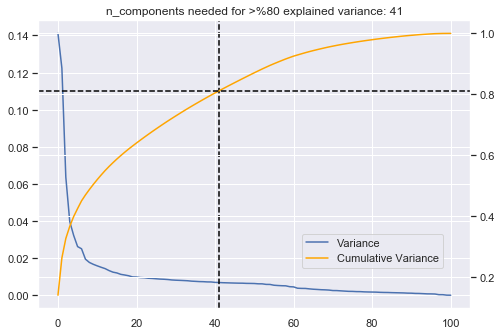

```python
n_components = min(np.where(np.cumsum(pca.explained_variance_ratio_)>0.8)[0]+1)

fig = plt.figure()
ax = fig.add_axes([0,0,1,1],True)
ax2 = ax.twinx()
ax.plot(pca.explained_variance_ratio_, label='Variance',)
ax2.plot(np.cumsum(pca.explained_variance_ratio_), label='Cumulative Variance',color = 'orange');
ax.set_title('n_components needed for >%80 explained variance: {}'.format(n_components));
ax.axvline(n_components, linestyle='dashed', color='black')
ax2.axhline(np.cumsum(pca.explained_variance_ratio_)[n_components], linestyle='dashed', color='black')
fig.legend(loc=(0.6,0.2));
```

```python
pca = PCA(n_components=n_components, random_state=42)
```

```python
pop_pca = pca.fit_transform(pop_float)
```

```python
pca.explained_variance_ratio_.sum()
```

```
0.8850348252734119
```

```python
def get_kmeans_score(data, k):
    kmeans = KMeans(n_clusters=k, random_state=42)
    model = kmeans.fit(data)
    score = np.abs(model.score(data))
    return score
```

```python
scores = []
ks = list(range(2,31, 5))
for k in ks:
    scores.append(get_kmeans_score(pop_pca, k))
```

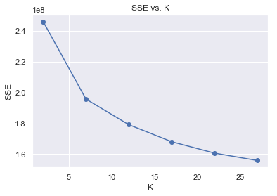

```python
plt.plot(ks, scores, marker='o');
plt.xlabel('K');
plt.ylabel('SSE');
plt.title('SSE vs. K');
```

As the reduction in Standard Squared Error of becomes very slow after 20 clusters, I decided to divide the population data into 20 clusters and proceed further.

```python
k = 20
```

```python
kmeans = KMeans(n_clusters=k, random_state=42, n_jobs=-1)
```

```python
model_pop = kmeans.fit(pop_pca)
```

```python
pop_pred = model_pop.predict(pop_pca) + 1
```

```python
cust_pca = pca.transform(cust_scaled)
```

```python
cust_pred = model_pop.predict(cust_pca) + 1
```

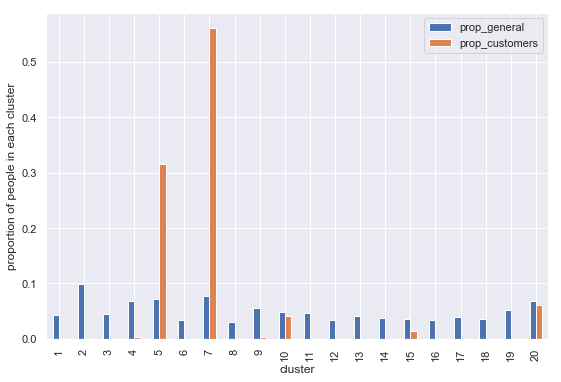

```python
general_prop = []
customers_prop = []
x = range(1, k+1)
for i in range(1, k+1):
    general_prop.append((pop_pred == i).sum()/len(pop_pred))
    customers_prop.append((cust_pred == i).sum()/len(cust_pred))


df_prop = pd.DataFrame({'cluster' : x, 'prop_general' : general_prop, 'prop_customers':customers_prop})

#ax = sns.countplot(x='index', y = df_general['prop_1', 'prop_2'], data=df_general )
df_prop.plot(x='cluster', y = ['prop_general', 'prop_customers'], kind='bar', figsize=(9,6))
plt.ylabel('proportion of people in each cluster')
plt.show()
```

From the above graph, the customers are highly represented in the clusters where the orang bar is relatively longer than blue bar. Now let's try to interpret the components of the cluster which is mostly represents the consumers to understand the characteristics of the people that are assigned to that cluster.

```python
pd.Series(cust_pred).value_counts()
```

```
7     107407
5      60570
20     11732
10      7990
15      2592
4        599
9        583
1        122
8         57
dtype: int64
```

```python
df_prop["diff"] = (df_prop["prop_customers"] - df_prop["prop_general"])/df_prop["prop_general"]
```

```python
df_prop["diff"]
```

```
0    -0.985334
1    -1.000000
2    -1.000000
3    -0.954304
4     3.433332
5    -1.000000
6     6.278808
7    -0.990280
8    -0.944614
9    -0.147798
10   -1.000000
11   -1.000000
12   -1.000000
13   -1.000000
14   -0.615008
15   -1.000000
16   -1.000000
17   -1.000000
18   -1.000000
19   -0.102635
Name: diff, dtype: float64
```

```python
sorted_by_diff = df_prop.sort_values(by=["diff"], ascending=False)["cluster"]
```

Finding out the most highly representative cluster for the customers.

```python
most_likely_cust_cluster = sorted_by_diff.iloc[0]
```

```python
most_likely_cust_cluster
```

```
7
```

Listing out all the clusters that the customers are represented by.

```python
cust_in_most_likely_cust_cluster = cust_pca[cust_pred == most_likely_cust_cluster]
```

```python
def pca_weights(pca, i):
    weight_map = {}
    for counter, feature in enumerate(common_cols):
        weight_map[feature] = pca.components_[i][counter]

    sorted_weights = sorted(weight_map.items(), key=operator.itemgetter(1), reverse=True)

    return sorted_weights
```

I want to find out the principal component in which the customers in highly representative cluster differ significantly from the rest of the population. For that I am relying upon the distance of mean of the values of each component in terms of standard deviations and sorting them by that distance in decreasing order to see which component has highest distance from the mean.

```python
comp_significance = pd.DataFrame({"comp": range(pop_pca.shape[1]), "dist_in_std" : (cust_in_most_likely_cust_cluster.mean(axis=0) - pop_pca.mean(axis=0))/pop_pca.std(axis=0)})
```

```python
comp_significance.head()
```

|  | comp | dist_in_std |
| --- | --- | --- |
| 0 | 0 | -0.781943 |
| 1 | 1 | -0.839045 |
| 2 | 2 | 0.350259 |
| 3 | 3 | -0.216549 |
| 4 | 4 | 0.598783 |

```python
comp_significance["abs_dist_in_std"] = comp_significance["dist_in_std"].abs()
```

```python
comp_sorted = comp_significance.sort_values(by=["abs_dist_in_std"], ascending=False)
```

```python
comp_sorted
```

|  | comp | dist_in_std | abs_dist_in_std |
| --- | --- | --- | --- |
| 25 | 25 | 3.444522 | 3.444522 |
| 11 | 11 | -2.932276 | 2.932276 |
| 36 | 36 | 2.895844 | 2.895844 |
| 39 | 39 | -2.777980 | 2.777980 |
| 37 | 37 | -2.389181 | 2.389181 |
| 9 | 9 | 2.366031 | 2.366031 |
| 10 | 10 | -1.784908 | 1.784908 |
| 40 | 40 | -1.686472 | 1.686472 |
| 19 | 19 | 1.460177 | 1.460177 |
| 17 | 17 | 1.262314 | 1.262314 |
| 22 | 22 | -1.137180 | 1.137180 |
| 16 | 16 | -1.085370 | 1.085370 |
| 1 | 1 | -0.839045 | 0.839045 |
| 0 | 0 | -0.781943 | 0.781943 |
| 34 | 34 | 0.768361 | 0.768361 |
| 26 | 26 | 0.761952 | 0.761952 |
| 20 | 20 | 0.760289 | 0.760289 |
| 32 | 32 | -0.681589 | 0.681589 |
| 31 | 31 | 0.673963 | 0.673963 |
| 15 | 15 | -0.663307 | 0.663307 |
| 18 | 18 | -0.625633 | 0.625633 |
| 21 | 21 | -0.611187 | 0.611187 |
| 4 | 4 | 0.598783 | 0.598783 |
| 29 | 29 | 0.576125 | 0.576125 |
| 27 | 27 | 0.554718 | 0.554718 |
| 14 | 14 | 0.537877 | 0.537877 |
| 2 | 2 | 0.350259 | 0.350259 |
| 23 | 23 | -0.334734 | 0.334734 |
| 8 | 8 | 0.295253 | 0.295253 |
| 6 | 6 | 0.264152 | 0.264152 |
| 3 | 3 | -0.216549 | 0.216549 |
| 24 | 24 | -0.199810 | 0.199810 |
| 5 | 5 | -0.149867 | 0.149867 |
| 35 | 35 | -0.141209 | 0.141209 |
| 33 | 33 | -0.097684 | 0.097684 |
| 12 | 12 | -0.094276 | 0.094276 |
| 7 | 7 | 0.086506 | 0.086506 |
| 28 | 28 | -0.053814 | 0.053814 |
| 30 | 30 | 0.032653 | 0.032653 |
| 13 | 13 | 0.030747 | 0.030747 |
| 38 | 38 | 0.021212 | 0.021212 |

It is clear that component number 25 is having highest distance of values from the rest of the population. We can take a look at the weights associated with the original input variables for that component to see which variables have highest positive or negative influence on deciding the value of this component.

```python
pprint.pprint(pca_weights(pca, comp_sorted.iloc[0, 0]))
```

```
[('D19_HAUS_DEKO', 0.16412879955334464),
 ('RT_SCHNAEPPCHEN', 0.11648645490452936),
 ('FINANZTYP', 0.11107742240149958),
 ('D19_SONSTIGE', 0.10546766858274352),
 ('FINANZ_ANLEGER', 0.09780059410031197),
 ('D19_GESAMT_ONLINE_DATUM', 0.0841001694156468),
 ('SEMIO_SOZ', 0.07982797061244255),
 ('D19_BILDUNG', 0.07367075415617678),
 ('CJT_GESAMTTYP', 0.07103124410270022),
 ('D19_RATGEBER', 0.06398787167250329),
 ('CJT_TYP_3', 0.06382174954152343),
 ('CJT_TYP_5', 0.060079088612023095),
 ('KOMBIALTER', 0.05940756911162346),
 ('CJT_TYP_6', 0.05826175909273628),
 ('D19_SAMMELARTIKEL', 0.05643487159713055),
 ('D19_BANKEN_ONLINE_DATUM', 0.05144177352221758),
 ('D19_BANKEN_DIREKT', 0.04946619205119535),
 ('D19_VERSAND_OFFLINE_DATUM', 0.045893486255317154),
 ('CJT_KATALOGNUTZER', 0.043376760651107585),
 ('SEMIO_KRIT', 0.04128208719663421),
 ('D19_TELKO_MOBILE', 0.038268997607484936),
 ('D19_TECHNIK', 0.03524415373906046),
 ('D19_BEKLEIDUNG_GEH', 0.03423660158502428),
 ('D19_WEIN_FEINKOST', 0.03327107055603341),
 ('D19_BEKLEIDUNG_REST', 0.032369139810439575),
 ('CJT_TYP_4', 0.02974827102494253),
 ('D19_BIO_OEKO', 0.029344976420352935),
 ('FINANZ_VORSORGER', 0.02931122259962965),
 ('FINANZ_SPARER', 0.02612916932705461),
 ('D19_VOLLSORTIMENT', 0.02233316696992287),
 ('D19_TELKO_DATUM', 0.021906410070969867),
 ('SEMIO_REL', 0.02069349404695816),
 ('D19_KOSMETIK', 0.020427124640224285),
 ('D19_GARTEN', 0.020350745635207994),
 ('SEMIO_DOM', 0.017863317870217776),
 ('FINANZ_UNAUFFAELLIGER', 0.012997008657081578),
 ('D19_VERSICHERUNGEN', 0.011470677299649968),
 ('D19_NAHRUNGSERGAENZUNG', 0.01031141782277961),
 ('D19_VERSI_DATUM', 0.010208397877405864),
 ('ONLINE_AFFINITAET', 0.00920596555989553),
```

[output cut: 46 more lines]

```
 ('D19_BANKEN_GROSS', -0.06547446518654554),
 ('SEMIO_VERT', -0.06899807898428274),
 ('D19_BANKEN_REST', -0.07140382149476654),
 ('D19_VERSAND_DATUM', -0.07315236268580792),
 ('LP_STATUS_FEIN', -0.07668936314109612),
 ('D19_VERSI_OFFLINE_DATUM', -0.07956642706206399),
 ('ALTERSKATEGORIE_GROB', -0.08641920674836051),
 ('HH_EINKOMMEN_SCORE', -0.08946844726830798),
 ('SEMIO_RAT', -0.11734645901215784),
 ('SEMIO_TRADV', -0.1244329382324566),
 ('D19_REISEN', -0.16941629232115055),
 ('D19_VERSAND_REST', -0.17436804647622306),
 ('SEMIO_ERL', -0.19497011251374569),
 ('SEMIO_MAT', -0.4906162333137957),
 ('SEMIO_LUST', -0.637466548486126)]
```

```python
pprint.pprint(pca_weights(pca, comp_sorted.iloc[1, 0]))
```

```
[('KOMBIALTER', 0.5119648952690264),
 ('SEMIO_REL', 0.25948234263488257),
 ('SEMIO_FAM', 0.2156482151757325),
 ('SEMIO_LUST', 0.2110120624653668),
 ('CJT_TYP_3', 0.20486480057541961),
 ('CJT_KATALOGNUTZER', 0.19615182006783274),
 ('CJT_TYP_4', 0.17423014533164252),
 ('GFK_URLAUBERTYP', 0.16833640883166445),
 ('CJT_TYP_6', 0.16173296675974788),
 ('D19_VERSAND_ONLINE_DATUM', 0.14933164929413997),
 ('CJT_TYP_5', 0.1473490433440154),
 ('CJT_GESAMTTYP', 0.14200709562553174),
 ('SEMIO_MAT', 0.11926310829172278),
 ('D19_TECHNIK', 0.11586776671402665),
 ('D19_REISEN', 0.11026281902897038),
 ('D19_KOSMETIK', 0.10675279810988693),
 ('FINANZ_UNAUFFAELLIGER', 0.09592713833674178),
 ('D19_HANDWERK', 0.0911257963176962),
 ('D19_VERSI_DATUM', 0.08867818324455332),
 ('FINANZ_ANLEGER', 0.08772767104085305),
 ('D19_BUCH_CD', 0.08758018494977982),
 ('D19_GESAMT_ONLINE_DATUM', 0.08545144285963001),
 ('FINANZ_HAUSBAUER', 0.08325574821354803),
 ('D19_SAMMELARTIKEL', 0.08227039322320204),
 ('RT_SCHNAEPPCHEN', 0.07911005104925219),
 ('D19_VOLLSORTIMENT', 0.07574886819611784),
 ('D19_VERSICHERUNGEN', 0.07343397301634404),
 ('SEMIO_KRIT', 0.06640225504924151),
 ('D19_BEKLEIDUNG_REST', 0.060774859660296346),
 ('D19_WEIN_FEINKOST', 0.0579326775717299),
 ('D19_KONSUMTYP_MAX', 0.056056031701545585),
 ('D19_RATGEBER', 0.05590489804307951),
 ('D19_BILDUNG', 0.0547851273694773),
 ('RETOURTYP_BK_S', 0.051152870961456855),
 ('D19_HAUS_DEKO', 0.05114232087131687),
 ('SEMIO_PFLICHT', 0.04871686574741421),
 ('D19_NAHRUNGSERGAENZUNG', 0.044441358398180156),
 ('D19_VERSAND_DATUM', 0.04365851850649385),
 ('FINANZ_VORSORGER', 0.04341323057373156),
 ('D19_DROGERIEARTIKEL', 0.043271812765703896),
```

[output cut: 46 more lines]

```
 ('D19_BANKEN_DATUM', -0.018662637865066303),
 ('FINANZ_MINIMALIST', -0.019454558077367734),
 ('ANREDE_KZ', -0.023190081701672294),
 ('D19_VERSAND_OFFLINE_DATUM', -0.04279987883924727),
 ('SEMIO_RAT', -0.04694138462836495),
 ('ZABEOTYP', -0.0754029652583942),
 ('SEMIO_SOZ', -0.07742812297529521),
 ('SEMIO_TRADV', -0.10878020667667362),
 ('LP_STATUS_GROB', -0.11193929971332911),
 ('D19_GESAMT_OFFLINE_DATUM', -0.12016298898269957),
 ('D19_GESAMT_DATUM', -0.12175425466078349),
 ('SEMIO_ERL', -0.12588836660676095),
 ('HH_EINKOMMEN_SCORE', -0.12996429781783647),
 ('SEMIO_VERT', -0.1303396159081691),
 ('LP_STATUS_FEIN', -0.21268602651331867)]
```

Looking at the original attributes that have highest absolute weight and the directionality based on the positive or negative sign of the coefficient for top two most influencial components in the highly representative cluster, it seems that some of the attributes that best describes the customers are:

- Female (ANDERE_KZ)
- Sensual minded (SEMIO_LUST)
- Materialistic minded (SEMIO_MAT)
- Young (ALTERSKATEGORIE_GROS)
- House owner or top earner (LP_STATUS_GROB, LP_STATUS_FEIN)
- Financially well prepared (FINANZTYP)
- Religious and familiar minded (SEMIO_REL, SEMIO_FAM)

As the company has cosmetics as one of their product groups, the data suggests that sensual minded young female are more likely to buy such products.

The remaining parts are continued in sepearate file `Part 2 Supervised Learning and Part 3 Kaggle.ipynb`